# DEFENSIVE TRAITS M.polymorpha SIBECOL 2025

Andrés Delgado Galán

2025-05-18

### M.polymorpha - PRODUCCIÓN DE FLORES

**sqrt(flor) ~ trat + clip + trat:clip**  
n = **51**

R² = **0.1571401**

##### MEflor Post-hoc Comparisons with Tukeys HSD

| contrast | trat | estimate | SE | df | t.ratio | p.value |
| --- | --- | --- | --- | --- | --- | --- |
| no - yes | ex | 0.5659454 | 0.8338463 | 47 | 0.6787166 | 0.5006460 |
| no - yes | gra | 1.6336429 | 0.9944868 | 47 | 1.6426995 | 0.1071198 |

| contrast | clip | estimate | SE | df | t.ratio | p.value |
| --- | --- | --- | --- | --- | --- | --- |
| ex - gra | no | -2.686741 | 0.9823584 | 47 | -2.734990 | 0.0087711 |
| ex - gra | yes | -1.619043 | 0.8481012 | 47 | -1.909021 | 0.0623756 |

ANOVA Results for MEflor Model

| Response | Predictor | Sum Sq | Df | F value | Pr(>F) |
| --- | --- | --- | --- | --- | --- |
| ME flor | trat ** | 52.603 | 1 | 10.448 | 0.002 |
| ME flor | clip | 12.498 | 1 | 2.482 | 0.122 |
| ME flor | trat:clip | 3.408 | 1 | 0.677 | 0.415 |
| ME flor | Residuals | 236.642 | 47 | NA | NA |

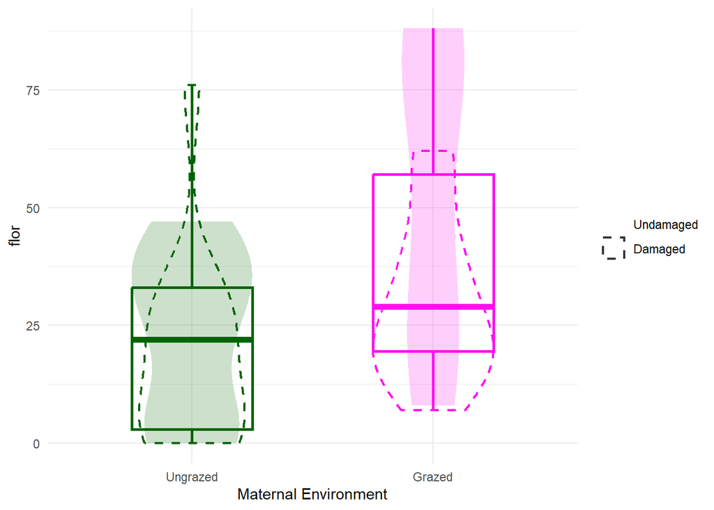

### M.polymorpha - PRODUCCIÓN DE FRUTOS

**sqrt(fruto) ~ trat + clip + trat:clip**  
n = **51**

R² = **0.1381171**

##### MEfruto Post-hoc Comparisons with Tukeys HSD

| contrast | trat | estimate | SE | df | t.ratio | p.value |
| --- | --- | --- | --- | --- | --- | --- |
| no - yes | ex | 0.7360772 | 0.8469512 | 47 | 0.8690904 | 0.3892143 |
| no - yes | gra | 1.0260070 | 1.0101163 | 47 | 1.0157315 | 0.3149577 |

| contrast | clip | estimate | SE | df | t.ratio | p.value |
| --- | --- | --- | --- | --- | --- | --- |
| ex - gra | no | -2.254781 | 0.9977974 | 47 | -2.259758 | 0.0285121 |
| ex - gra | yes | -1.964851 | 0.8614301 | 47 | -2.280918 | 0.0271300 |

ANOVA Results for MEfruto Model

| Response | Predictor | Sum Sq | Df | F value | Pr(>F) |
| --- | --- | --- | --- | --- | --- |
| ME fruto | trat ** | 53.299 | 1 | 10.261 | 0.002 |
| ME fruto | clip | 9.031 | 1 | 1.739 | 0.194 |
| ME fruto | trat:clip | 0.251 | 1 | 0.048 | 0.827 |
| ME fruto | Residuals | 244.138 | 47 | NA | NA |

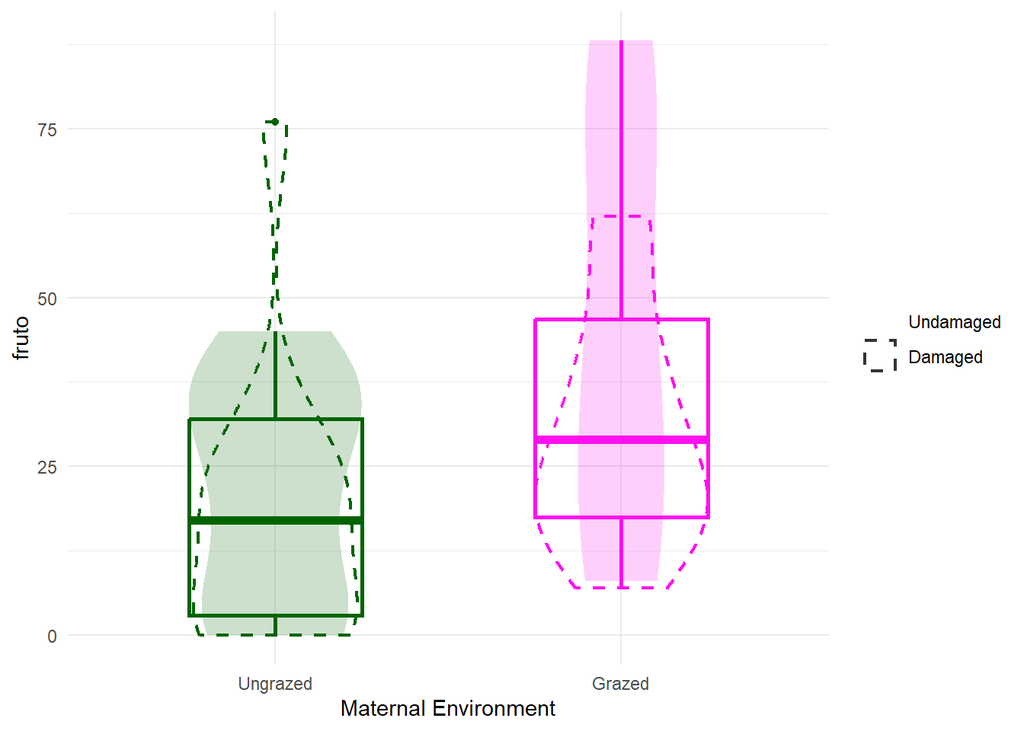

### M.polymorpha - PRODUCCIÓN DE MEJAS

**sqrt(hojas) ~ trat + clip + trat:clip**  
n = **52**

R² = **0.0414068**

##### MEhojas Post-hoc Comparisons with Tukeys HSD

| contrast | trat | estimate | SE | df | t.ratio | p.value |
| --- | --- | --- | --- | --- | --- | --- |
| no - yes | ex | 1.985632 | 1.623748 | 48 | 1.222870 | 0.2273493 |
| no - yes | gra | 3.773357 | 1.970841 | 48 | 1.914592 | 0.0615151 |

| contrast | clip | estimate | SE | df | t.ratio | p.value |
| --- | --- | --- | --- | --- | --- | --- |
| ex - gra | no | -1.6638809 | 1.946805 | 48 | -0.8546725 | 0.3969783 |
| ex - gra | yes | 0.1238443 | 1.652489 | 48 | 0.0749441 | 0.9405707 |

ANOVA Results for MEhojas Model

| Response | Predictor | Sum Sq | Df | F value | Pr(>F) |
| --- | --- | --- | --- | --- | --- |
| ME hojas | trat | 4.864 | 1 | 0.246 | 0.622 |
| ME hojas | clip * | 92.364 | 1 | 4.671 | 0.036 |
| ME hojas | trat:clip | 9.692 | 1 | 0.490 | 0.487 |
| ME hojas | Residuals | 949.161 | 48 | NA | NA |

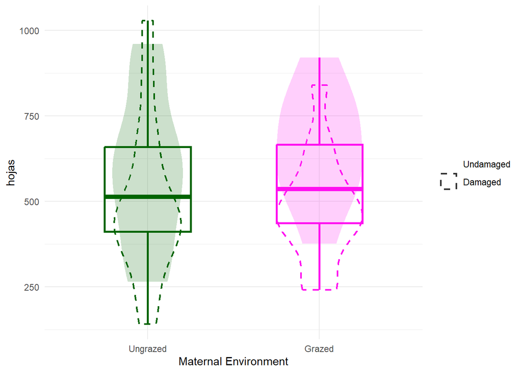

### M.polymorpha - ALTURA MÁXIMA

**sqrt(altura) ~ trat + clip + trat:clip**  
n = **55**

R² = **0.5872188**

##### MEaltura Post-hoc Comparisons with Tukeys HSD

| contrast | trat | estimate | SE | df | t.ratio | p.value |
| --- | --- | --- | --- | --- | --- | --- |
| no - yes | ex | 2.808466 | 0.4159382 | 51 | 6.752124 | 0e+00 |
| no - yes | gra | 2.666922 | 0.4560024 | 51 | 5.848482 | 4e-07 |

| contrast | clip | estimate | SE | df | t.ratio | p.value |
| --- | --- | --- | --- | --- | --- | --- |
| ex - gra | no | 0.0651968 | 0.4411690 | 51 | 0.1477820 | 0.8830976 |
| ex - gra | yes | -0.0763478 | 0.4316394 | 51 | -0.1768786 | 0.8603043 |

ANOVA Results for MEaltura Model

| Response | Predictor | Sum Sq | Df | F value | Pr(>F) |
| --- | --- | --- | --- | --- | --- |
| ME altura | trat | 0.001 | 1 | 0.001 | 0.982 |
| ME altura | clip *** | 103.470 | 1 | 79.743 | 0.000 |
| ME altura | trat:clip | 0.068 | 1 | 0.053 | 0.820 |
| ME altura | Residuals | 66.174 | 51 | NA | NA |

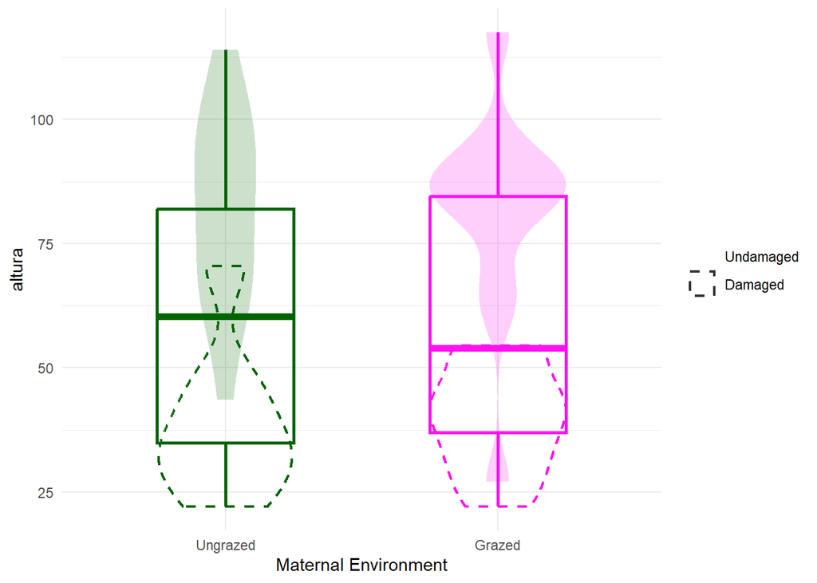

### M.polymorpha - SEMILLAS/FRUTO

**sqrt(seedfruto) ~ trat + clip + trat:clip**  
n = **46**

R² = **0.0446915**

##### MEseedfruto Post-hoc Comparisons with Tukeys HSD

| contrast | trat | estimate | SE | df | t.ratio | p.value |
| --- | --- | --- | --- | --- | --- | --- |
| no - yes | ex | 0.2167319 | 0.1079562 | 42 | 2.0075917 | 0.0511488 |
| no - yes | gra | -0.0353030 | 0.0989104 | 42 | -0.3569187 | 0.7229397 |

| contrast | clip | estimate | SE | df | t.ratio | p.value |
| --- | --- | --- | --- | --- | --- | --- |
| ex - gra | no | 0.0606974 | 0.1057925 | 42 | 0.5737403 | 0.5692034 |
| ex - gra | yes | -0.1913375 | 0.1012213 | 42 | -1.8902892 | 0.0656327 |

ANOVA Results for MEseedfruto Model

| Response | Predictor | Sum Sq | Df | F value | Pr(>F) |
| --- | --- | --- | --- | --- | --- |
| ME seedfruto | trat | 0.057 | 1 | 0.939 | 0.338 |
| ME seedfruto | clip | 0.073 | 1 | 1.195 | 0.281 |
| ME seedfruto | trat:clip · | 0.181 | 1 | 2.963 | 0.093 |
| ME seedfruto | Residuals | 2.564 | 42 | NA | NA |

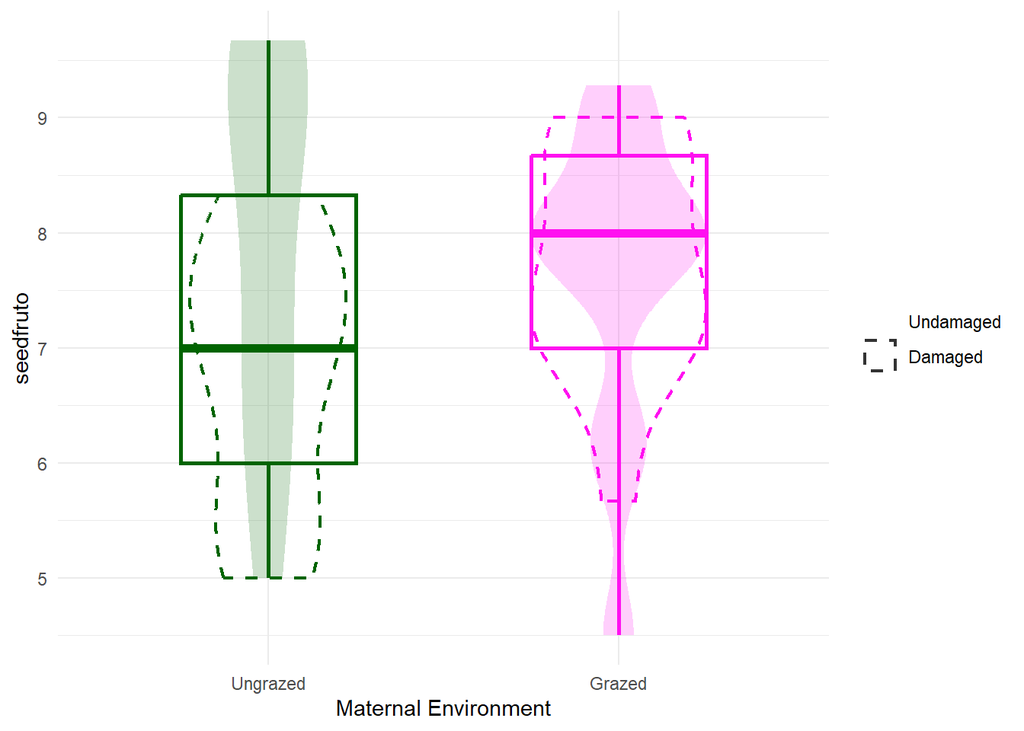

### M.polymorpha - PRODUCCIÓN DE SEMILLAS

**sqrt(seedtotal) ~ trat + clip + trat:clip**  
n = **51**

R² = **0.0221215**

##### MEseedtotal Post-hoc Comparisons with Tukeys HSD

| contrast | trat | estimate | SE | df | t.ratio | p.value |
| --- | --- | --- | --- | --- | --- | --- |
| no - yes | ex | 1.782685 | 2.742058 | 47 | 0.6501266 | 0.5187758 |
| no - yes | gra | -1.424402 | 2.798601 | 47 | -0.5089691 | 0.6131551 |

| contrast | clip | estimate | SE | df | t.ratio | p.value |
| --- | --- | --- | --- | --- | --- | --- |
| ex - gra | no | -2.004876 | 2.798601 | 47 | -0.7163852 | 0.4772983 |
| ex - gra | yes | -5.211963 | 2.742058 | 47 | -1.9007485 | 0.0634774 |

ANOVA Results for MEseedtotal Model

| Response | Predictor | Sum Sq | Df | F value | Pr(>F) |
| --- | --- | --- | --- | --- | --- |
| ME seedtotal | trat · | 168.906 | 1 | 3.456 | 0.069 |
| ME seedtotal | clip | 0.572 | 1 | 0.012 | 0.914 |
| ME seedtotal | trat:clip | 32.745 | 1 | 0.670 | 0.417 |
| ME seedtotal | Residuals | 2297.019 | 47 | NA | NA |

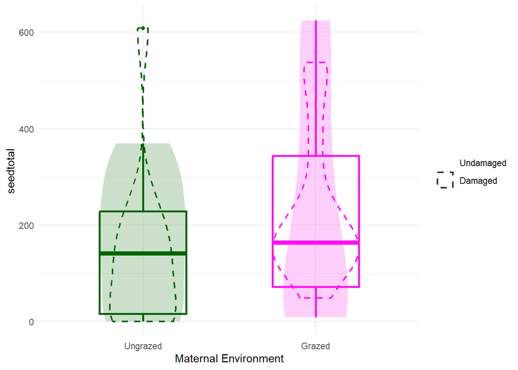

### M.polymorpha - PESO MEDIO DE LAS SEMILLAS

**sqrt(massseed) ~ trat + clip + trat:clip**  
n = **47**

R² = **-0.0438307**

##### MEmassseed Post-hoc Comparisons with Tukeys HSD

| contrast | trat | estimate | SE | df | t.ratio | p.value |
| --- | --- | --- | --- | --- | --- | --- |
| no - yes | ex | -0.0000776 | 0.0030760 | 43 | -0.0252336 | 0.9799854 |
| no - yes | gra | -0.0027358 | 0.0028879 | 43 | -0.9473549 | 0.3487518 |

| contrast | clip | estimate | SE | df | t.ratio | p.value |
| --- | --- | --- | --- | --- | --- | --- |
| ex - gra | no | 0.0005135 | 0.0030113 | 43 | 0.1705253 | 0.8653969 |
| ex - gra | yes | -0.0021447 | 0.0029554 | 43 | -0.7257115 | 0.4719472 |

ANOVA Results for MEmassseed Model

| Response | Predictor | Sum Sq | Df | F value | Pr(>F) |
| --- | --- | --- | --- | --- | --- |
| ME massseed | trat | 0.000 | 1 | 0.159 | 0.692 |
| ME massseed | clip | 0.000 | 1 | 0.501 | 0.483 |
| ME massseed | trat:clip | 0.000 | 1 | 0.397 | 0.532 |
| ME massseed | Residuals | 0.002 | 43 | NA | NA |

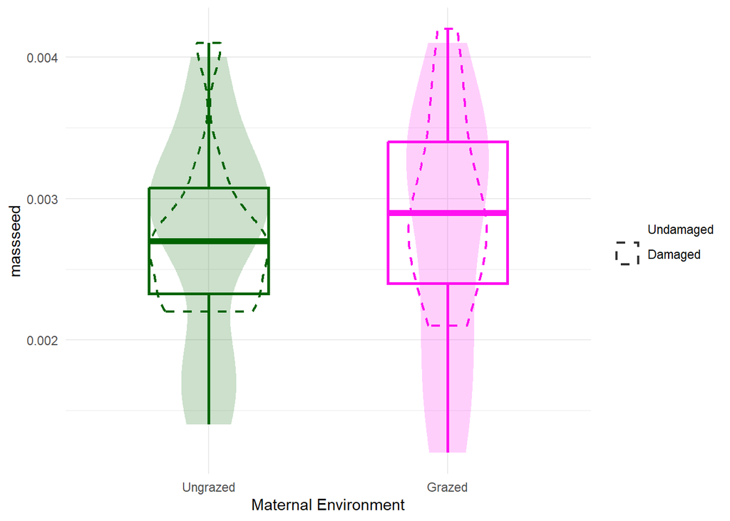

### M.polymorpha - SLA

**log(SLA) ~ trat + clip + trat:clip**  
n = **44**

R² = **-0.0278169**

##### MESLA Post-hoc Comparisons with Tukeys HSD

| contrast | trat | estimate | SE | df | t.ratio | p.value |
| --- | --- | --- | --- | --- | --- | --- |
| no - yes | ex | -0.0642163 | 0.0900464 | 40 | -0.7131461 | 0.4798955 |
| no - yes | gra | -0.0354060 | 0.1045188 | 40 | -0.3387524 | 0.7365682 |

| contrast | clip | estimate | SE | df | t.ratio | p.value |
| --- | --- | --- | --- | --- | --- | --- |
| ex - gra | no | 0.0650713 | 0.1010769 | 40 | 0.6437801 | 0.5233924 |
| ex - gra | yes | 0.0938816 | 0.0938936 | 40 | 0.9998723 | 0.3233829 |

ANOVA Results for MESLA Model

| Response | Predictor | Sum Sq | Df | F value | Pr(>F) |
| --- | --- | --- | --- | --- | --- |
| ME SLA | trat | 0.069 | 1 | 1.371 | 0.249 |
| ME SLA | clip | 0.029 | 1 | 0.580 | 0.451 |
| ME SLA | trat:clip | 0.002 | 1 | 0.044 | 0.836 |
| ME SLA | Residuals | 2.024 | 40 | NA | NA |

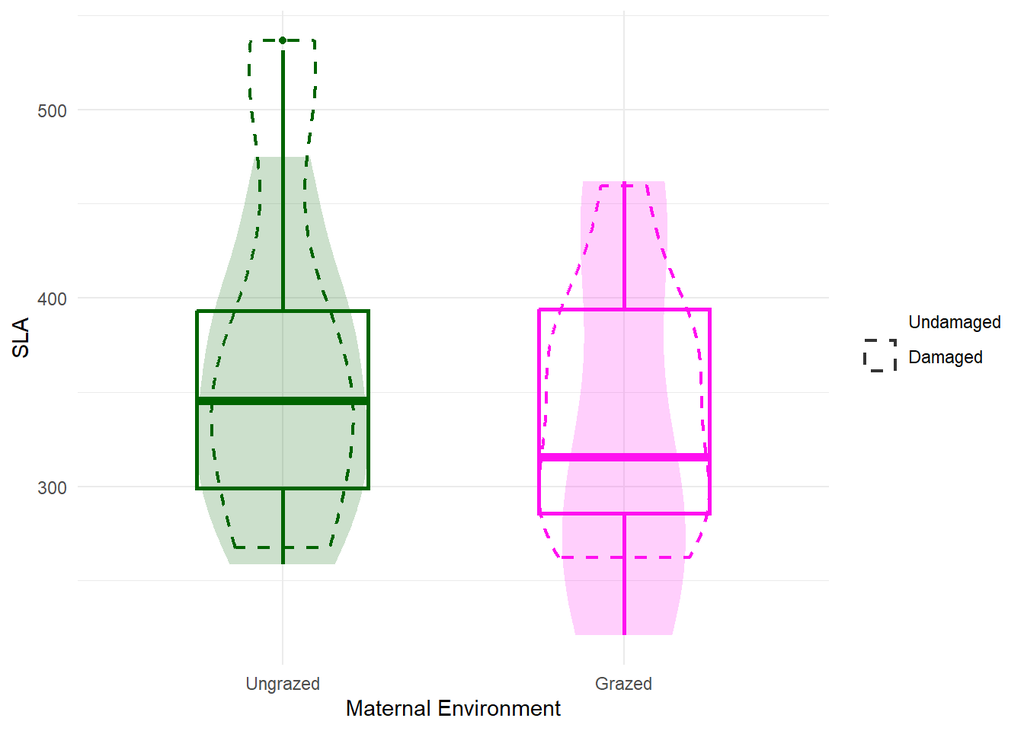

### M.polymorpha - LDMC

**sqrt(LDMC) ~ trat + clip + trat:clip**  
n = **47**

R² = **0.1091829**

##### MELDMC Post-hoc Comparisons with Tukeys HSD

| contrast | trat | estimate | SE | df | t.ratio | p.value |
| --- | --- | --- | --- | --- | --- | --- |
| no - yes | ex | 0.0350722 | 0.0127575 | 43 | 2.7491467 | 0.0087017 |
| no - yes | gra | -0.0077042 | 0.0136451 | 43 | -0.5646085 | 0.5752738 |

| contrast | clip | estimate | SE | df | t.ratio | p.value |
| --- | --- | --- | --- | --- | --- | --- |
| ex - gra | no | 0.0291658 | 0.0134045 | 43 | 2.175827 | 0.0351099 |
| ex - gra | yes | -0.0136106 | 0.0130101 | 43 | -1.046151 | 0.3013367 |

ANOVA Results for MELDMC Model

| Response | Predictor | Sum Sq | Df | F value | Pr(>F) |
| --- | --- | --- | --- | --- | --- |
| ME LDMC | trat | 0.001 | 1 | 0.585 | 0.449 |
| ME LDMC | clip | 0.003 | 1 | 2.633 | 0.112 |
| ME LDMC | trat:clip * | 0.005 | 1 | 5.244 | 0.027 |
| ME LDMC | Residuals | 0.044 | 43 | NA | NA |

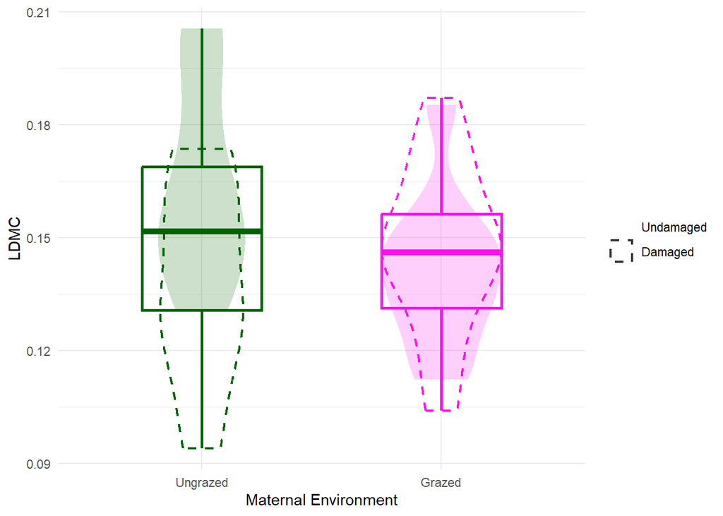

### M.polymorpha - ÁREA FOLIAR

**sqrt(area.m) ~ trat + clip + trat:clip**  
n = **49**

R² = **0.0230626**

##### MEarea.m Post-hoc Comparisons with Tukeys HSD

| contrast | trat | estimate | SE | df | t.ratio | p.value |
| --- | --- | --- | --- | --- | --- | --- |
| no - yes | ex | 0.0528184 | 0.1797382 | 45 | 0.2938631 | 0.7702137 |
| no - yes | gra | 0.2814071 | 0.1998089 | 45 | 1.4083809 | 0.1658902 |

| contrast | clip | estimate | SE | df | t.ratio | p.value |
| --- | --- | --- | --- | --- | --- | --- |
| ex - gra | no | -0.3186269 | 0.1962847 | 45 | -1.6232897 | 0.1115131 |
| ex - gra | yes | -0.0900383 | 0.1835804 | 45 | -0.4904569 | 0.6261937 |

ANOVA Results for MEarea.m Model

| Response | Predictor | Sum Sq | Df | F value | Pr(>F) |
| --- | --- | --- | --- | --- | --- |
| ME area.m | trat | 0.469 | 1 | 2.152 | 0.149 |
| ME area.m | clip | 0.293 | 1 | 1.346 | 0.252 |
| ME area.m | trat:clip | 0.158 | 1 | 0.723 | 0.400 |
| ME area.m | Residuals | 9.799 | 45 | NA | NA |

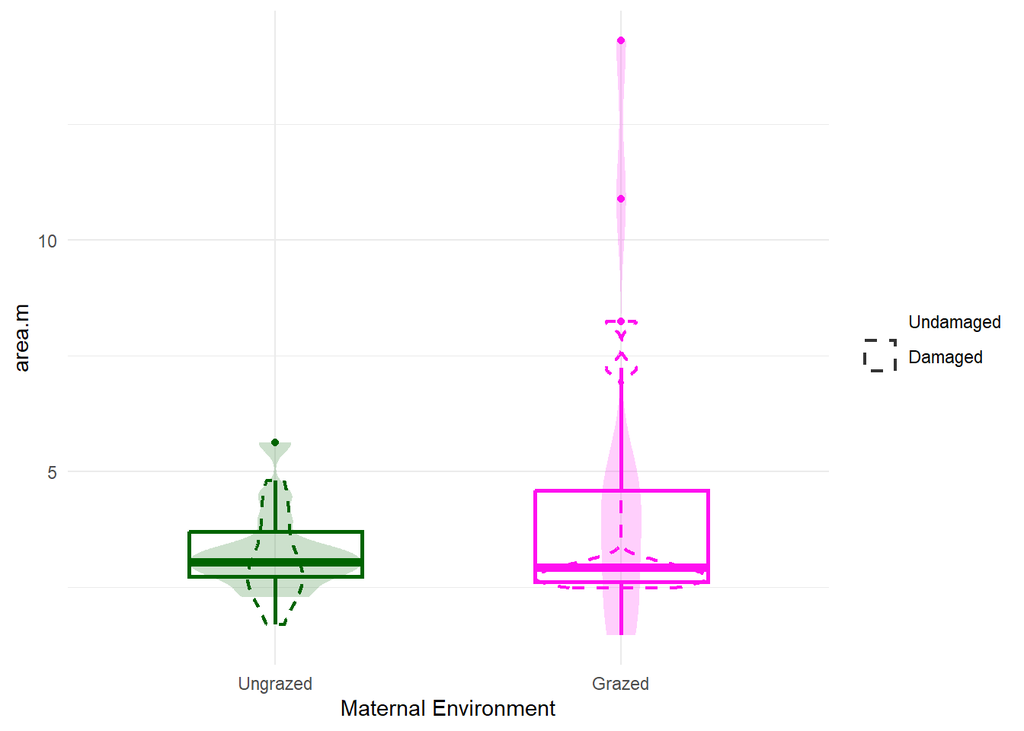

Quité los valores extremos con el SLA y tampoco salía bien. Habría que mirar estos valores de area foliar tan altos pero aún así no parece haber ningún patrón.

### M.polymorpha - FENOLOGÍA DE FLORACIÓN

**log(dias_flor) ~ trat + clip + trat:clip**  
n = **52**

R² = **0.2381044**

##### MEdias_flor Post-hoc Comparisons with Tukeys HSD

| contrast | trat | estimate | SE | df | t.ratio | p.value |
| --- | --- | --- | --- | --- | --- | --- |
| no - yes | ex | 0.0251551 | 0.0686436 | 48 | 0.3664594 | 0.7156328 |
| no - yes | gra | 0.1290725 | 0.0750032 | 48 | 1.7208931 | 0.0917111 |

| contrast | clip | estimate | SE | df | t.ratio | p.value |
| --- | --- | --- | --- | --- | --- | --- |
| ex - gra | no | 0.1387544 | 0.0761957 | 48 | 1.821027 | 0.0748389 |
| ex - gra | yes | 0.2426719 | 0.0673174 | 48 | 3.604888 | 0.0007409 |

ANOVA Results for MEdias_flor Model

| Response | Predictor | Sum Sq | Df | F value | Pr(>F) |
| --- | --- | --- | --- | --- | --- |
| ME dias_flor | trat *** | 0.501 | 1 | 15.267 | 0.000 |
| ME dias_flor | clip | 0.067 | 1 | 2.051 | 0.159 |
| ME dias_flor | trat:clip | 0.034 | 1 | 1.045 | 0.312 |
| ME dias_flor | Residuals | 1.575 | 48 | NA | NA |

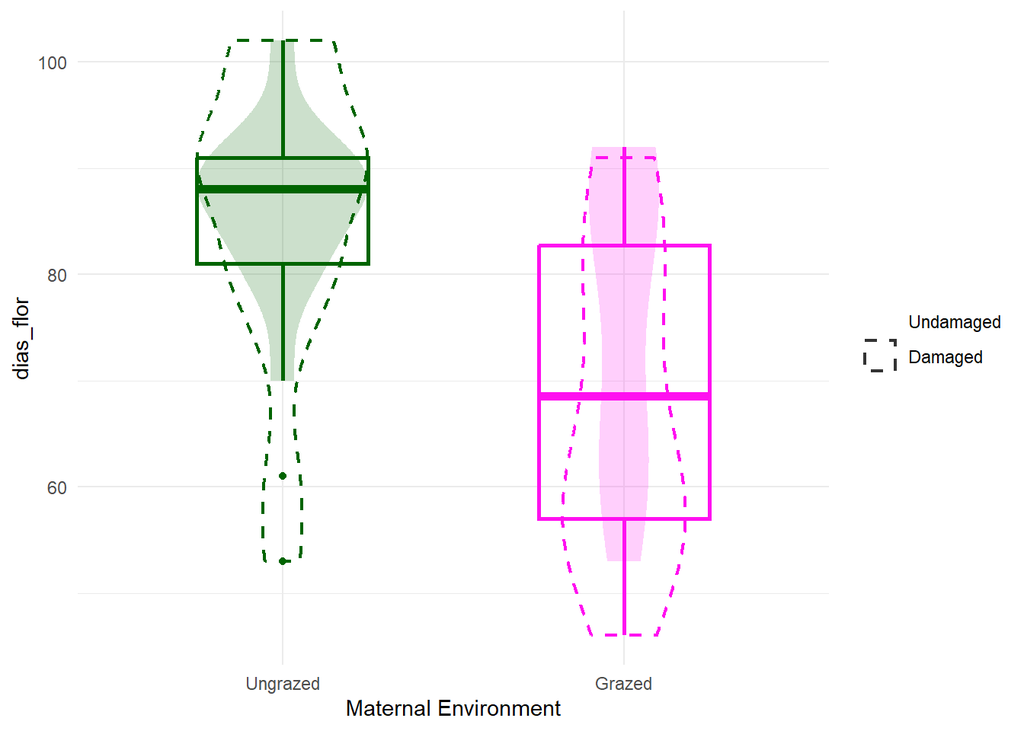

### M.polymorpha - FENOLOGÍA DE FRUCTIFICACÓN

**sqrt(dias_fruto) ~ trat + clip + trat:clip**  
n = **48**

R² = **0.2636842**

##### MEdias_fruto Post-hoc Comparisons with Tukeys HSD

| contrast | trat | estimate | SE | df | t.ratio | p.value |
| --- | --- | --- | --- | --- | --- | --- |
| no - yes | ex | -0.201738 | 0.2614668 | 44 | -0.7715625 | 0.4444977 |
| no - yes | gra | 0.622286 | 0.2890624 | 44 | 2.1527737 | 0.0368595 |

| contrast | clip | estimate | SE | df | t.ratio | p.value |
| --- | --- | --- | --- | --- | --- | --- |
| ex - gra | no | 0.2693133 | 0.2890624 | 44 | 0.9316786 | 0.3565869 |
| ex - gra | yes | 1.0933372 | 0.2614668 | 44 | 4.1815528 | 0.0001357 |

ANOVA Results for MEdias_fruto Model

| Response | Predictor | Sum Sq | Df | F value | Pr(>F) |
| --- | --- | --- | --- | --- | --- |
| ME dias_fruto | trat *** | 6.170 | 1 | 13.884 | 0.001 |
| ME dias_fruto | clip | 0.338 | 1 | 0.760 | 0.388 |
| ME dias_fruto | trat:clip * | 1.986 | 1 | 4.470 | 0.040 |
| ME dias_fruto | Residuals | 19.552 | 44 | NA | NA |

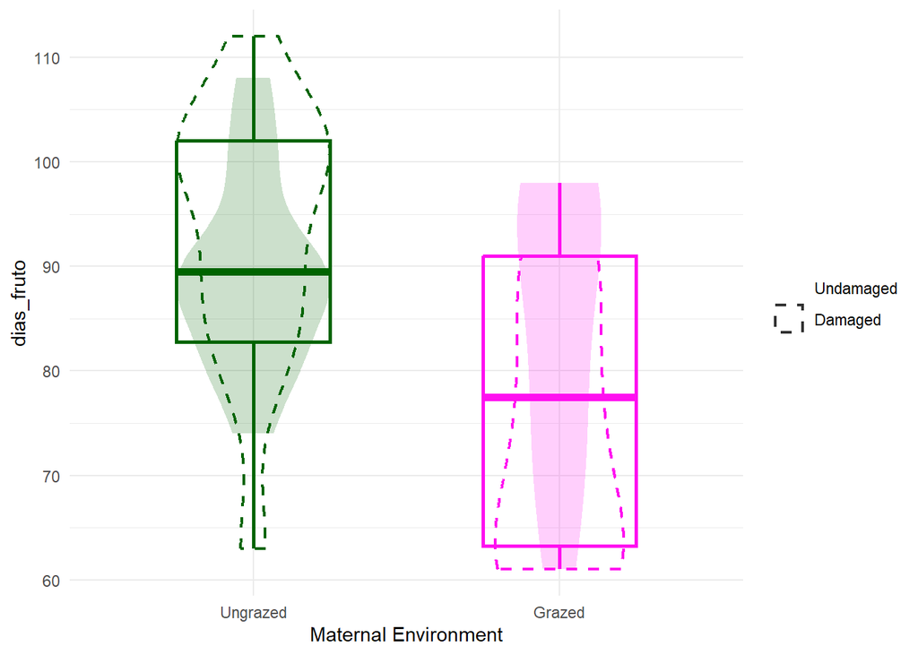

### M.polymorpha - PERIODO DE FLORACIÓN

**sqrt(periodo_flor) ~ trat + clip + trat:clip**  
n = **47**

R² = **0.2348089**

##### MEperiodo_flor Post-hoc Comparisons with Tukeys HSD

| contrast | trat | estimate | SE | df | t.ratio | p.value |
| --- | --- | --- | --- | --- | --- | --- |
| no - yes | ex | -0.5703529 | 0.5542239 | 43 | -1.0291021 | 0.3091858 |
| no - yes | gra | -0.4630724 | 0.6003381 | 43 | -0.7713527 | 0.4447162 |

| contrast | clip | estimate | SE | df | t.ratio | p.value |
| --- | --- | --- | --- | --- | --- | --- |
| ex - gra | no | -1.614327 | 0.6104854 | 43 | -2.644334 | 0.0113800 |
| ex - gra | yes | -1.507047 | 0.5430263 | 43 | -2.775275 | 0.0081316 |

ANOVA Results for MEperiodo_flor Model

| Response | Predictor | Sum Sq | Df | F value | Pr(>F) |
| --- | --- | --- | --- | --- | --- |
| ME periodo_flor | trat *** | 28.132 | 1 | 14.677 | 0.000 |
| ME periodo_flor | clip | 3.137 | 1 | 1.637 | 0.208 |
| ME periodo_flor | trat:clip | 0.033 | 1 | 0.017 | 0.896 |
| ME periodo_flor | Residuals | 82.418 | 43 | NA | NA |

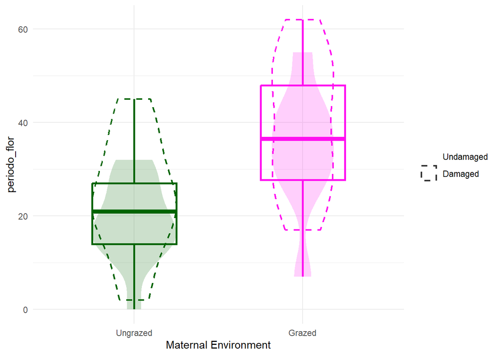

### M.polymorpha - PERIODO DE FRUCTIFICACIÓN

**sqrt(periodo_fruto) ~ trat + clip + trat:clip**

n = **44**

R² = **0.2977441**

##### MEperiodo_fruto Post-hoc Comparisons with Tukeys HSD

| contrast | trat | estimate | SE | df | t.ratio | p.value |
| --- | --- | --- | --- | --- | --- | --- |
| no - yes | ex | -0.215641 | 0.5763368 | 40 | -0.374158 | 0.7102629 |
| no - yes | gra | -0.760178 | 0.6088315 | 40 | -1.248585 | 0.2190755 |

| contrast | clip | estimate | SE | df | t.ratio | p.value |
| --- | --- | --- | --- | --- | --- | --- |
| ex - gra | no | -1.519862 | 0.6205786 | 40 | -2.449105 | 0.0187977 |
| ex - gra | yes | -2.064399 | 0.5636685 | 40 | -3.662435 | 0.0007238 |

ANOVA Results for MEperiodo_fruto Model

| Response | Predictor | Sum Sq | Df | F value | Pr(>F) |
| --- | --- | --- | --- | --- | --- |
| ME periodo_fruto | trat *** | 36.201 | 1 | 18.990 | 0.000 |
| ME periodo_fruto | clip | 2.435 | 1 | 1.277 | 0.265 |
| ME periodo_fruto | trat:clip | 0.804 | 1 | 0.422 | 0.520 |
| ME periodo_fruto | Residuals | 76.253 | 40 | NA | NA |

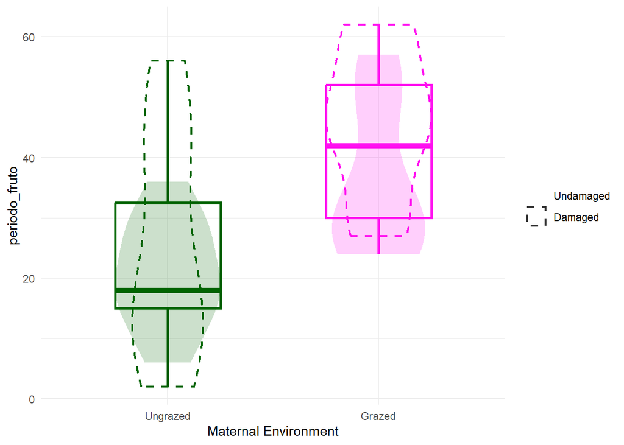

### M.polymorpha - ESPERANZA DE VIDA

**sqrt(dias_muerte) ~ trat + clip + trat:clip**  
n = **56**

R² = **-0.0252034**

##### MEdias_muerte Post-hoc Comparisons with Tukeys HSD

| contrast | trat | estimate | SE | df | t.ratio | p.value |
| --- | --- | --- | --- | --- | --- | --- |
| no - yes | ex | -0.2300329 | 0.2869081 | 52 | -0.8017650 | 0.4263377 |
| no - yes | gra | 0.2563100 | 0.3091046 | 52 | 0.8292015 | 0.4107807 |

| contrast | clip | estimate | SE | df | t.ratio | p.value |
| --- | --- | --- | --- | --- | --- | --- |
| ex - gra | no | -0.1344018 | 0.3043120 | 52 | -0.4416581 | 0.6605679 |
| ex - gra | yes | 0.3519410 | 0.2919865 | 52 | 1.2053331 | 0.2335313 |

ANOVA Results for MEdias_muerte Model

| Response | Predictor | Sum Sq | Df | F value | Pr(>F) |
| --- | --- | --- | --- | --- | --- |
| ME dias_muerte | trat | 0.196 | 1 | 0.318 | 0.575 |
| ME dias_muerte | clip | 0.000 | 1 | 0.001 | 0.981 |
| ME dias_muerte | trat:clip | 0.821 | 1 | 1.330 | 0.254 |
| ME dias_muerte | Residuals | 32.103 | 52 | NA | NA |

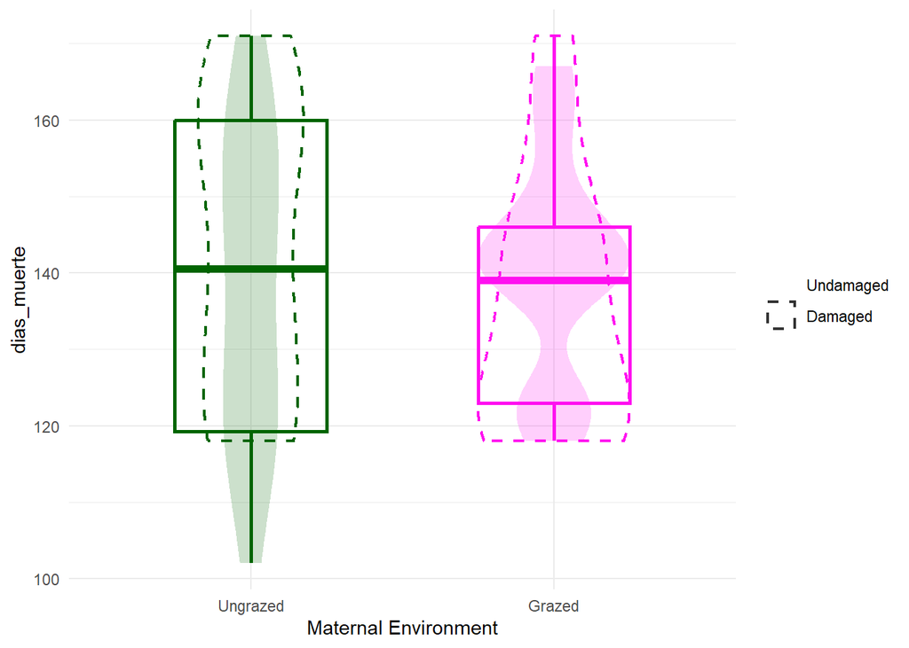

### M.polymorpha - FENOLES

**sqrt(fenoles) ~ trat + clip + trat:clip**  
n = **39**

R² = **-0.0065441**

##### MEfenoles Post-hoc Comparisons with Tukeys HSD

| contrast | trat | estimate | SE | df | t.ratio | p.value |
| --- | --- | --- | --- | --- | --- | --- |
| no - yes | ex | -0.2715218 | 0.3842221 | 35 | -0.7066793 | 0.4844442 |
| no - yes | gra | -0.5023299 | 0.3371652 | 35 | -1.4898626 | 0.1452176 |

| contrast | clip | estimate | SE | df | t.ratio | p.value |
| --- | --- | --- | --- | --- | --- | --- |
| ex - gra | no | 0.1703723 | 0.3554033 | 35 | 0.4793774 | 0.6346521 |
| ex - gra | yes | -0.0604358 | 0.3674173 | 35 | -0.1644880 | 0.8702933 |

ANOVA Results for MEfenoles Model

| Response | Predictor | Sum Sq | Df | F value | Pr(>F) |
| --- | --- | --- | --- | --- | --- |
| ME fenoles | trat | 0.033 | 1 | 0.053 | 0.819 |
| ME fenoles | clip | 1.573 | 1 | 2.515 | 0.122 |
| ME fenoles | trat:clip | 0.127 | 1 | 0.204 | 0.654 |
| ME fenoles | Residuals | 21.883 | 35 | NA | NA |

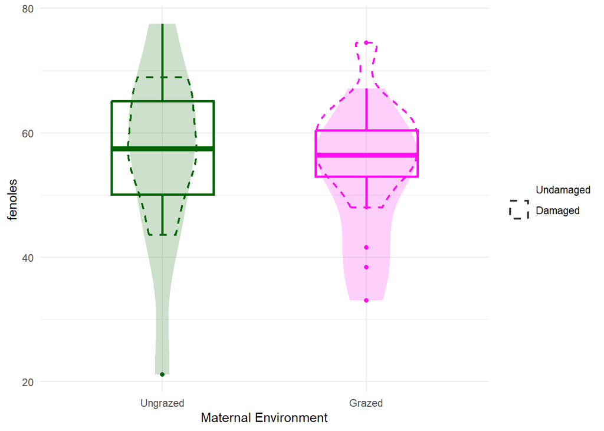